# STN Speech Neurons (sanity check)

Author

Josef Mana

Published

March 6, 2024

In this report, I compare estimates of contact locations as extracted from:

1. (pre-/peri-)surgery protocols (‘check’ data set),
2. (post-)surgery imaging via Lead-DBS (‘perm’ data set).

To this end I estimated coordinates (in native and MNI spaces) of the most distal and proximal contacts of the permanent electrode (I don’t use the other contacts to evade shinanigans with directional St. Jude leads).

## 1 Procedures for contact coordinates estimation

Using the pre- and peri-surgery protocols, I used the following procedure (resulting into the ‘check’ data set):

1. co-register and normalise pre-surgery MR images (T1w used for planning as well as postop. CT) via Lead-DBS,
2. locate sites that were targeted by the permanent electrodes (from peri-surgery protocols),
3. extract midpoint of the most distal and proximal contacts of the target for permanent electrode (0.75 mm superior of distal edge of the contact along the lead),
4. rotate each point by arc and ring angles in Leksell space,
5. transform Leksell space coordinates to ‘raw’ DICOM space (i.e., the space as represented by raw DICOM files) via transformation derived from pre-surgery protocol,
6. transform ‘raw’ space coordinates to ‘native’ space coordinates via transformation used by Lead-DBS for prepocessing of the MR images,
7. transform ‘native’ space coordinates to MNI coordinates via Lead-DBS-derived non-linear normalisation transform.

Using Lead-DBS I used the following procedure (resulting into the ‘perm’ data set):

1. co-register and normalise pre-surgery MR and CT images via Lead-DBS (identical to step one above),
2. pre-locate electrode artifact using PaCER or TRAC/CORE algorithm,
3. manually wiggle localisation result where needed,
4. extract coordinates from the “ea_reconstruction.mat” file.

These resulted into two data sets estimating the same contact locations as inferred by pre- and peri-surgery planning (the ‘check’ data set) and as inferred by post-surgery CT artifact via Lead-DBS (the ‘perm’ data set).

## 2 Data set

This is how the raw data look like (with id = patient’s REDCap id, cont = contact (distal vs proximal), side = hemisphere, ctqual = quality of CT scan, space = native vs MNI, axis = left-right (x) vs anterior-posterior (y) vs top-bottom (z), source = check (using the first procedure above) vs perm (using the second procedure above), estimate = estimated coordinates in mm):

```r
# list packages to be used
pkgs <- c( "here", "dplyr", "tidyverse" )

# load or install each of the packages as needed
for ( i in pkgs ) {
  if ( i %in% rownames( installed.packages() ) == F ) install.packages(i) # install if it ain't installed yet
  if ( i %in% names( sessionInfo()$otherPkgs ) == F ) library( i , character.only = T ) # load if it ain't loaded yet
}

# where the data is?
indir <- here( "_nogithub", "coords" ) # directory containing inputs

# read the data
for ( i in c("perm","check") ) assign( paste0( "d.", i ), read.csv( paste0( indir, "/coords_", i, ".csv" ), sep = "," ) )


# ---- in-house functions ---

# angle between two vectors
ang <- function( x, y ) {

  dp <- x %*% y # dot (inner) product
  nx <- sqrt( x %*% x ) # norm of vector x
  ny <- sqrt( y %*% y ) # norm of vector y

  theta <- acos( dp / (nx * ny ) ) # final angle in radians
  return( as.numeric( ( theta / pi ) * 180 ) ) # return the results in degrees
}


# ---- pre-processing ----

# prepare a common data set for angles as well as distances calculatio
d0 <- d.perm %>%

  # keep only native and MNI coordinates
  filter( space != "scrf" ) %>%

  # reformat some variables so the files mix well
  mutate(
    source = "perm", # label the source of estimation ('perm' for permanent electrode)
    side = case_when( hemisphere == "left" ~ "sin", hemisphere == "right" ~ "dex" ), # re-code according to d.targ
    space = ifelse( space == "native", "nat", space ), # re-code according to d.targ
    # keep only the most proximal and distal contacts (the others won't work for St. Jude)
    cont = case_when(
      contact == 1 ~ "dist",
      contact == 4 * ifelse( elmodel == "Medtronic 3389", 1, 2 ) ~ "prox"
    )
  ) %>%

  # keep only variables of interest and rows with data
  select( id, side, cont, source, x, y, z, space ) %>%
  filter( complete.cases(cont) ) %>%

  # re-format to a format ready to joining d.targ
  pivot_wider(
    id_cols = c("id","cont","side","source"),
    values_from = c("x","y","z"),
    names_from = space,
    names_glue = "{space}_{.value}"
  ) %>%

  # add d.targ and get rid of raw coordinates (which are not part of Lead-DBS output)
  full_join( d.check %>% mutate( source = "check", .after = side ) ) %>%
  mutate( ctqual = factor( ifelse( id %in% paste0( "IPN", c(243,244,248,256) ), "low", "ok" ), levels = c("ok","low"), ordered = T ) ) %>% # label low-qualty CT subjects
  select( -norm_algo, -contains("raw") ) %>%

  # put 'perm' and 'check' data next to each other to locate irrelevant rows (side not evaluated)
  pivot_wider(
    names_from = source,
    values_from = contains("_"),
    id_cols = c("id","cont","side","ctqual")
  ) %>%

  # keep only cases (sides) used for the experiment
  filter( complete.cases(nat_x_check) ) %>%

  # prepare unique rows for patient/space/source combinations
  pivot_longer(
    cols = contains("_"),
    names_to = c("space","axis","source"),
    names_pattern = "(.*)_(.*)_(.*)",
    values_to = "estimate"
  )

# calculate Eucledian distance between 'perm' and 'check' estimates
d1 <- d0  %>%

  # return coordinates to their own distinct columns
  pivot_wider(
    names_from = c("source","axis"),
    values_from = "estimate",
    id_cols = c("id","cont","side","space","ctqual")
  ) %>%

  # calculate the distances
  mutate(
    x_diff = perm_x - check_x,
    y_diff = perm_y - check_y,
    z_diff = perm_z - check_z,
    dist_mm = sqrt( x_diff^2 + y_diff^2 + z_diff^2 )
  )

# calculate angles w.r.t. YZ plane (alpha) and XZ plane (beta)
d2 <- d0 %>%

  # return coordinates to their own distinct columns
  pivot_wider(
    names_from = c("cont","axis"),
    values_from = "estimate",
    id_cols = c("id","side","space","source","ctqual")
  ) %>%

  # calculate the angles
  mutate(
    x = - prox_x + dist_x,
    y = - prox_y + dist_y,
    z = - prox_z + dist_z,
    alpha = sapply( 1:nrow(.), function(i) 90-ang( c(x[i],y[i],z[i]), c(1,0,0) ) ),
    beta = sapply( 1:nrow(.), function(i) 90-ang( c(x[i],y[i],z[i]), c(0,-1,0) ) )
  ) %>%

  # put the angles side-to-side
  pivot_wider(
    names_from = "source",
    values_from = c("alpha","beta"),
    id_cols = c("id","side","space","ctqual")
  ) %>%

  # compute angle differences
  mutate(
    alpha_diff = alpha_perm - alpha_check,
    beta_diff = beta_perm - beta_check
  )

# show the data
d0
```

| id | cont | side | ctqual | space | axis | source | estimate |
| --- | --- | --- | --- | --- | --- | --- | --- |
| IPN243 | dist | sin | low | nat | x | perm | -12.7278396 |
| IPN243 | dist | sin | low | nat | x | check | -14.2887020 |
| IPN243 | dist | sin | low | mni | x | perm | -11.1296000 |
| IPN243 | dist | sin | low | mni | x | check | -12.5128000 |
| IPN243 | dist | sin | low | nat | y | perm | -19.9092774 |
| IPN243 | dist | sin | low | nat | y | check | -16.7386805 |
| IPN243 | dist | sin | low | mni | y | perm | -14.5583000 |
| IPN243 | dist | sin | low | mni | y | check | -11.1637000 |
| IPN243 | dist | sin | low | nat | z | perm | 12.2935001 |
| IPN243 | dist | sin | low | nat | z | check | 16.3926298 |

[output cut: 326 more lines]

## 3 Distances distributions

To summarise distances between estimates of the identical contacts in the ‘check’ data vs the ‘perm’ data using this re-wranggled data (arranged from the largest difference at top to the smallest at bottom) for data (separately for native and MNI space):

```r
# prepare a table with summaries
t1 <- array( data = NA, dim = c(2,2,5),
             dimnames = list( c("nat","mni"), c("prox","dist"), c("mean","median","sd","min","max") )
             )

# fill-in
for( i in dimnames(t1)[[1]] ) {

  t1[ i , , ] <- sapply(
    # loop through all statistics of interest
    colnames(t1[i,,]),
    function(c)

      sapply(
        # loop through all contacts included
        rownames(t1[i,,]),
        function(r)
          do.call( c, list( with( d1, dist_mm[ space == i & cont == r] ) ) ) %>% round(2) %>% sprintf( "%.2f", . )

      )
  )

}

# show the data
arrange( d1[ d1$space == "nat", c("id","cont","side","ctqual","x_diff","y_diff","z_diff","dist_mm") ], by = desc(dist_mm ) )
arrange( d1[ d1$space == "mni", c("id","cont","side","ctqual","x_diff","y_diff","z_diff","dist_mm") ], by = desc(dist_mm ) )
```

Data of distances between ‘check’ vs ‘perm’ estimates (in mm)

native space

| id | cont | side | ctqual | x_diff | y_diff | z_diff | dist_mm |
| --- | --- | --- | --- | --- | --- | --- | --- |
| IPN243 | dist | sin | low | 1.5608624 | -3.17059683 | -4.0991297 | 5.4121937 |
| IPN243 | prox | sin | low | 1.7615145 | -2.43201115 | -3.9333931 | 4.9486557 |
| IPN272 | dist | sin | ok | -2.9722228 | -0.64234975 | 3.6520354 | 4.7522715 |
| IPN272 | prox | sin | ok | -2.7479943 | -0.39547393 | 3.6510831 | 4.5867505 |
| IPN274 | dist | sin | ok | 1.0729792 | -2.15371458 | -2.3214556 | 3.3434903 |
| IPN274 | prox | sin | ok | 1.3059126 | -1.73553406 | -2.3880640 | 3.2280545 |
| IPN263 | dist | sin | ok | 2.8884392 | -0.05331766 | 1.1515673 | 3.1099889 |
| IPN263 | prox | sin | ok | 2.8199965 | -0.07469558 | 1.1339173 | 3.0403500 |
| IPN285 | dist | sin | ok | 2.8890155 | 0.64227430 | 0.2484661 | 2.9699600 |
| IPN758 | dist | sin | ok | -0.6999718 | 0.46899132 | 2.7591338 | 2.8849146 |

[output cut: 18 more lines]

MNI space

| id | cont | side | ctqual | x_diff | y_diff | z_diff | dist_mm |
| --- | --- | --- | --- | --- | --- | --- | --- |
| IPN272 | dist | sin | ok | -3.01480 | 0.91240 | 4.24452 | 5.2855882 |
| IPN272 | prox | sin | ok | -2.90940 | 0.89160 | 3.93051 | 4.9707613 |
| IPN243 | dist | sin | low | 1.38320 | -3.39460 | -1.97141 | 4.1620919 |
| IPN243 | prox | sin | low | 1.55600 | -2.80613 | -1.48426 | 3.5353259 |
| IPN758 | dist | sin | ok | -0.23100 | -0.41920 | 3.25249 | 3.2875189 |
| IPN263 | prox | sin | ok | 2.86200 | -0.00800 | 1.33483 | 3.1579866 |
| IPN263 | dist | sin | ok | 2.90340 | 0.05510 | 1.22741 | 3.1526660 |
| IPN285 | dist | sin | ok | 2.77039 | 1.24290 | 0.13810 | 3.0395613 |
| IPN275 | dist | sin | ok | 2.77240 | 0.28050 | 0.68250 | 2.8689176 |
| IPN758 | prox | sin | ok | -0.30710 | 0.53910 | 2.59640 | 2.6695004 |

[output cut: 18 more lines]

Figure 1 shows distribution of these distances as well as association between proximal and distal distances conditional on space (native space in the left column, MNI space in the right column). Figure 1 (e) and Figure 1 (f) show that distances in estimates of proximal and distal contacts are similar within participant (i.e., points lying close to an ‘identity’ line, i.e., a line with zero intercept and slope of one on the mm of distance scale). Also, the lower-quality CT cases did not seem to result in a larger distance between estimates.

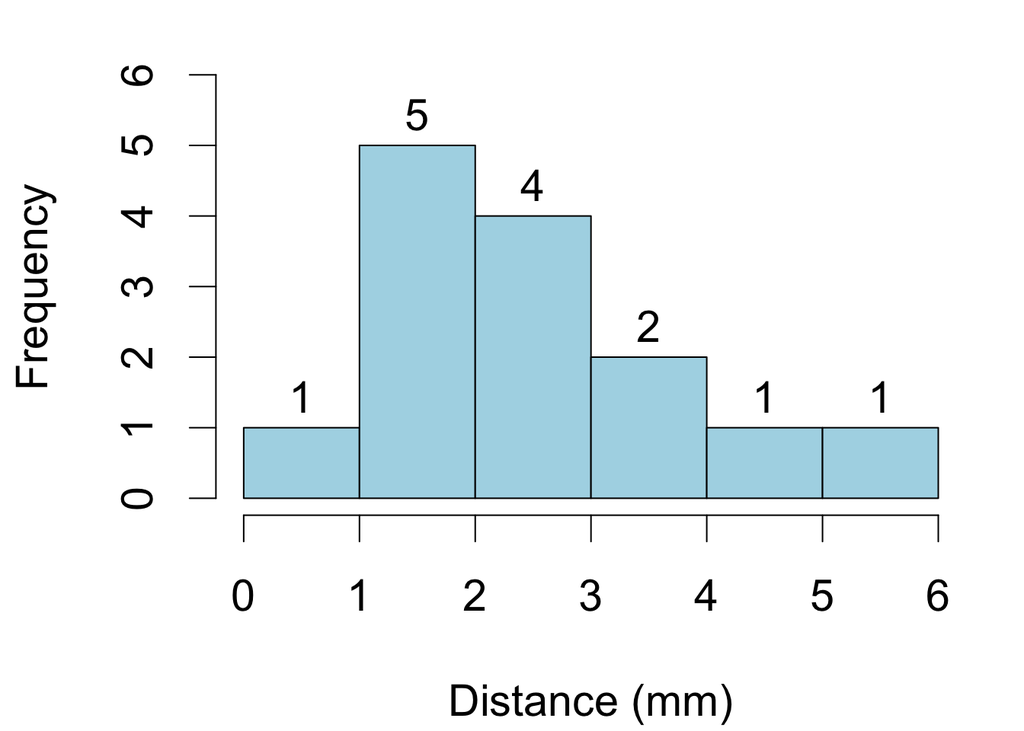

(a) Distribution of distal contact differences in native space

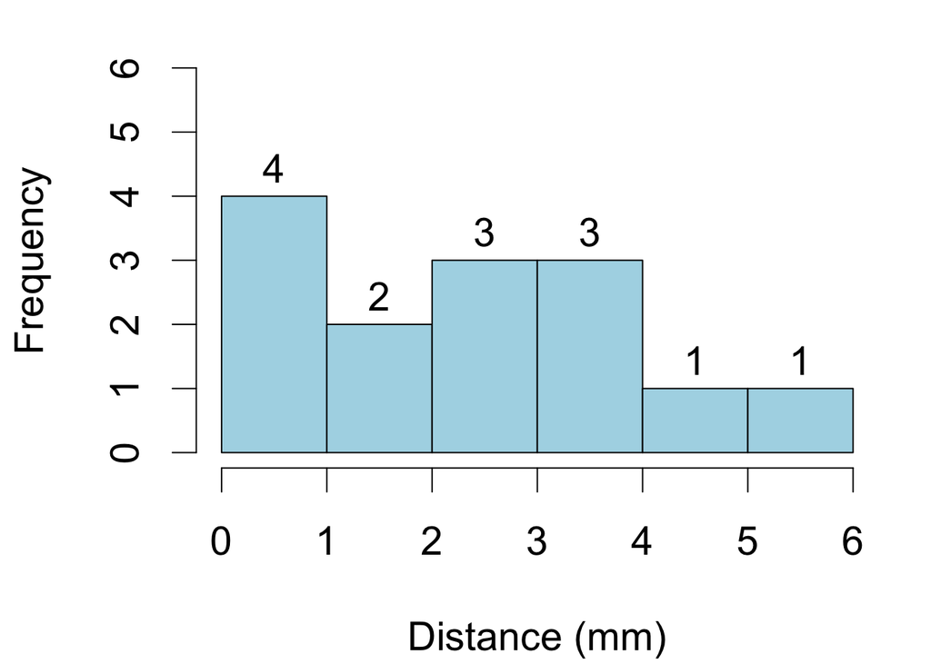

(b) Distribution of distal contact differences in MNI space

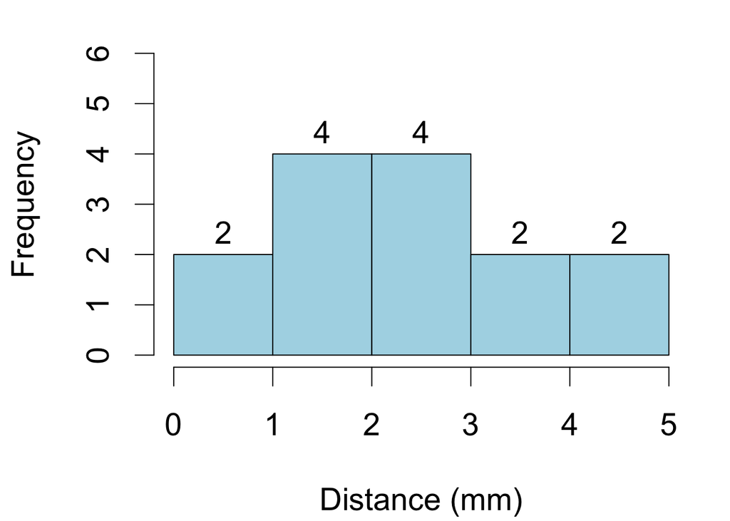

(c) Distribution of proximal contact differences in native space

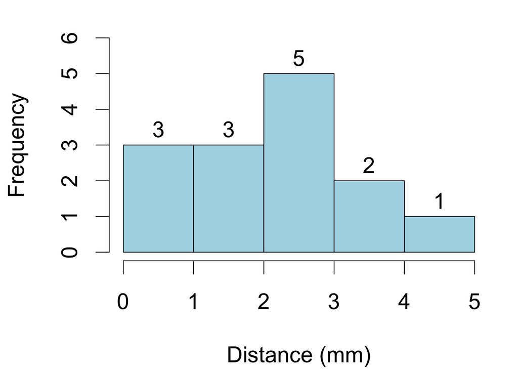

(d) Distribution of proximal contact differences in MNI space

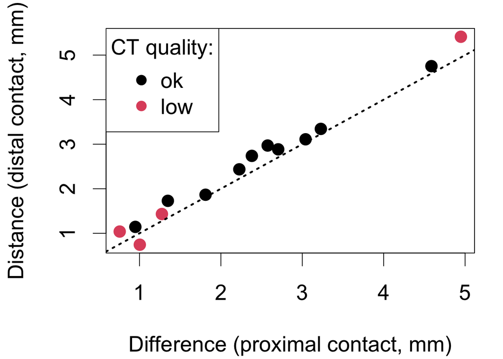

(e) Association between proximal and distal contact differences in native space

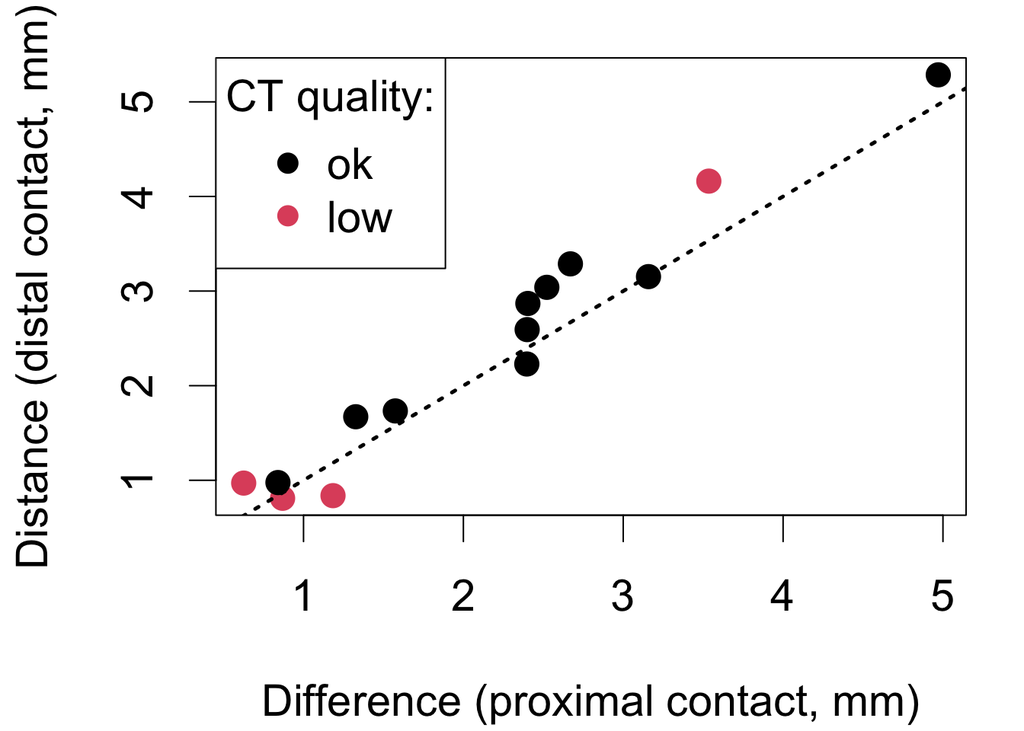

(f) Association between proximal and distal contact differences in MNI space

Figure 1: Euclidean distance between ‘check’ and ‘perm’ data for estimates of identical contacts

```r
par( cex = 1.8, mar = c(4,4,1,1)+.1 )

# plot histograms
for( i in c("dist","prox") ) for ( j in c("nat","mni") ) {

    h <- with( d1, hist( dist_mm[ cont == i & space == j ] , # plot the bars
                         xlab = "Distance (mm)", main = NULL, # wiggle labels
                         col = "lightblue", ylim = c(0,6) # stylise it
                         )
               )
    # add number of observations per bar
    with( h, text( mids, counts, labels = counts, adj = c(0.5,-0.5) ) )

}

# correlations
for ( i in c("nat","mni") ) {

    with( d1, plot( dist_mm[ space == i & cont == "prox" ], xlab = "Difference (proximal contact, mm)", # abscissa
                    dist_mm[ space == i & cont == "dist" ], ylab = "Distance (distal contact, mm)", # ordinate
                    col = ctqual[ space == i & cont == "prox" ], # colors
                    pch = 19, cex = 1.2 # stylising
                    )
          )
    # add legend for the colors
    with( d1, legend( "topleft",
                      legend = levels( ctqual ),
                      col = factor( levels(ctqual), levels = c("ok","low"), ordered = T ),
                      pch = 19, cex = 1, title = "CT quality:"
                      )
          )
    # show a line implying such a distribution
    abline( a = 0, b = 1, lty = 3, lwd = 2.5 )

}
```

## 4 Distances summary

In the native space, we observe a mean distance of 2.54 mm between estimated position of distal contacts (SD = 1.37, Md = 2.59, Min = 0.74, Max = 5.41), and mean distance of 2.35 mm between estimated position of proximal contacts (SD = 1.30, Md = 2.30, Min = 0.76, Max = 4.95).

In the MNI space, we observe a mean distance of 2.40 mm between estimated position of distal contacts (SD = 1.34, Md = 2.41, Min = 0.81, Max = 5.29), and mean distance of 2.18 mm between estimated position of proximal contacts (SD = 1.21, Md = 2.40, Min = 0.63, Max = 4.97).